# Лабораторная работа #1

# Задача

Дано уравнение Коши. Его необходимо решить и составить для него разностную схему (все это делается вне программы, вручную). Задача программы заключается в исследовании отклонения численного решения от точного.  
**Условия**: дано уравнение Коши  
**Результат**: вывести графики двух решений и проанализировать их

Здесь будет рассмотрен следующий вариант:
$$\begin{equation}
\tag{0}
y''+\frac{1}{π^2}y=\frac{1}{π^2cos(\frac{x}{π})},\quad
y(0) = 2,\quad
y'(0) = 0.
\end{equation}$$

## Часть 1. Подготовка данных для программы

Перед тем как писать программу, нужно привести наше уравнение к нужному виду. Во-первых, решить его, то есть найти точное решение. Во-вторых, необходимо составить разностную схему, которая и представляет наибольший интерес. Именно ее отклонение мы и будем исследовать.

### Шаг 1. Решение задачи Коши

Алгоритм решения задачи простой:

1. ищем решение общего однородного уравнения (обнуляем неоднородность справа)
2. методом вариации произвольных постоянных находим общее неоднородное
3. при помощи дополнительных условий находим неизвестые константы
4. получаем решение нашей задачи

### Шаг 2. Создание разностной схемы

Теперь необходимо сделать разностную схему, с помощью которой мы найдем численное значение функции. Для начала создадим сеточную функцию. Для этого нам понадобятся формулы:

$$\tag{2}
y'=\frac{U_{n+1}-U_n}{h}$$
$$\tag{3}
y'=\frac{U_{n+1}-U_{n-1}}{2h}$$
$$\tag{4}
U_0=y(0)$$
$$\tag{5}
U_1 = U_0 + hy`(0)=y(0)+hy`(0)$$

Обозначения:

- x<sub>n</sub> = n*h, *где h - шаг разностной схемы, который мы выберем сами, n - колличество этих шагов*
- y(x) = U(x)
- U(x<sub>n</sub>) = U<sub>n</sub>

Составляем сеточную функцию:

$$\begin{cases}
\tag{6}
\LARGE
\frac{U_{n+1}-2U_n+U_{n-1}}{h^2}+\frac{1}{π^2}U_n = \frac{1}{π^2cos\frac{nh}{π}},\quad \large 0\le n\le N,\\
\large
U_0=2, \quad \quad n = 0,\\
\large
U_1=2, \quad \quad n = 1.
\end{cases}$$
В первой строчке умножаем на h<sup>2</sup> и выражаем U<sub>n+1</sub>:

$$\tag{7}
\large
U_{n+1} = U_n(2-\frac{h^2}{π^2})-U_{n-1}+\frac{h^2}{π^2cos(\frac{nh}{π})}$$

Это и есть наша искомая разностная схема

Обратимся к определению: будем говорить, что разностная схема имеет порядок $r$, если для нахождения элемента $\small U_n$ необходимо знать $r$ предыдущих значений сеточной функции $\small (U_{n-1}, U_{n-2}, ..., U_{n-r})$

[output not shown]

[output not shown]

## Часть 2. Создание программы

Что нужно, чтобы код заработал? Правильно, шаг. Все, на что мы можем повлиять - это шаг, с которым будут “идти” наши функции. Задаем его. Любой: чем меньше - тем ближе численное значение будет к точному. Однако стоит помнить, что маленький шаг может заставить программу работать очень долго. Одной сотой вполне достаточно.

Здесь мы задаем шаг и создаем последовательность (массив) “иксов” - точки, в которых будут вычисляться все наши решения.

```r
h = 1e-2
x = seq(from = 0, to = pi^2/2, by = h) ## Создается последовательность иксов от нуля до (π^2)/2 с шагом h
x = x[-length(x)] ## Из последовательности иксов исключается точка (π^2)/2 (точка разрыва)
```

1. Выразить шаг через количество. Пусть $\small N$ - количество наших иксов, $\small a\le \small X\le \small b$, тогда $\small h = \frac{a - b}{N}$ и искать икс точно так же, как в коде выше.
2. Не записывать шаг вовсе, а задать икс через количество: $\small x = seq(from = a, to = b, length = N)$. Но нужно помнить, что нам все равно понадобится шаг в программе потом.

```r
y = (log(abs(cos(x/pi))) + 2) * cos(x/pi) + (x/pi)*sin(x/pi)
```

Здесь стоит заметить, что хотя в первой части мы и заменили $\small x$ на $\small nh$, но здесь будем пользоваться все равно обозначением $\small x$. Дело в том, что в нашем случае $\small x$ - это и есть набор всевозможных $\small nh$ . Также $\small pi$ - это не заданная нами переменная, а предоставляемая языком константа $\small π$.

Теперь нужно построить график нашей функции. Для этого воспользуемся функцией $\small plot(...)$:

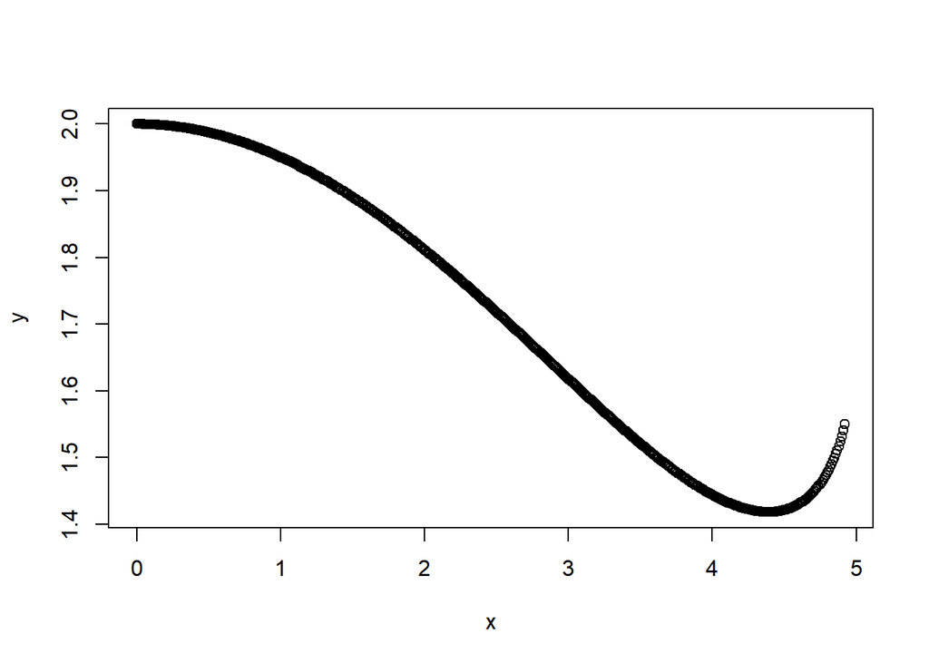

```r
plot(x,y)
```

Как можно увидеть, график действительно строится по точкам. Функция $\small plot(...)$ имеет много параметров. Можно менять цвет и тип отображения. Давайте для более логичного отображения воспользуемся параметром `type` и зададим ему значениe `"l"`, что превратит наш точечный график в сплошную линию. Так же поменяем цвет на синий.

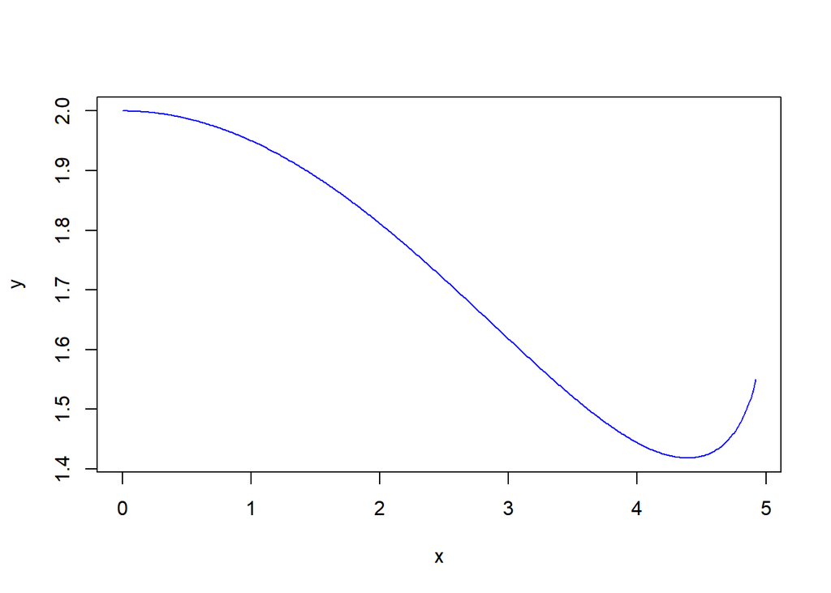

```r
plot(x, y, type = "l", col = "blue")
```

Отлично, график точного решения у нас есть. Теперь нужно найти наше численное решение.  
Помним, два первых начения у нас есть. Чтобы найти следующее, наша схема требует два предыдущих. Сделаем некоторые замены в уравнении (7):

- $U_{n+1} -> U_n$
- $U_n -> U_{n-1}$
- $U_{n-1} -> U_{n-2}$
- $cos\frac{nh}{π} -> cos\frac{x_n}{π}$

Теперь наше уравнение будет выглядеть следуюшим образом:

$$\tag{8}
\large
U_{n} = U_{n-1}(2-\frac{h^2}{π^2})-U_{n-2}+\frac{h^2}{π^2cos(\frac{x_n}{π})}$$
Вычисляться наша разностная схема будет по всем $\small x_n$ рекуррентно. Но не все будут использоваться: подсчет пойдет с $\small x_3$ так как для $\small x_2$ и $\small x_1$ значения вычислены: значения $\small U_0$ и $\small U_1$ (так как в **R** индексы в массивах начинаются с единицы, то наши $\small U_0$ и $\small U_1$ превращаются в $\small U_1$ и $\small U_2$ соответственно).

Таким образом, создаем набор $\small U$ и включаем в него два уже известных нам значения.

```r
u = c(2 , 2)
```

Введем временную переменную $\small n$ для цикла. Она будет варьироваться от $\small 3$ до длины набора $\small x$:

```r
n = 3:(length(x))
```

Теперь запускаем рекуррентное вычисление нашей разностной схемы. Для этого используем цикл по $\small n$ и функцию конкатенации $\small c(...)$. Записывается это так: в первый аргумент функции $\small c(...)$ мы передаем ранее вычисленный набор значений $\small U$, а во второй аргумент записываем правую часть нашей разнойстной схемы (в данном случае правая часть (8))

```r
for(n in 3:(length(x))){
  u = c(u,(-u[n-2] + u[n-1] * (2 - (h^2/pi^2)) + (h^2)/(cos(x[n]/pi) * pi^2)))
}
```

Теперь у нас есть набор точек, по которым вычислялась разностная схема, и набор значений в этих точках. Значит можно строить график. Если мы снова воспользуемся функцикй $\small plot(x, y, ...)$, то это создаст новый график, где будет отображно лишь численное решение. Нам же необходимо их сравнить. Поэтому будем “рисовать” уже на построенном ранее графике точного решения. Для этого воспользуемся функциями $\small points(x, y, ...)$ и $\small lines(x, y, ...)$. Они достраивают на существующем пространстве еще графики поточечно и непрерывно соответственно. У них есть похожие аргументы с функцией $\small plot(x, y, ...)$, такие как цвет. Предлагаю воспользоваться именно $\small lines(x, y,...)$. Сразу же пропишем цвет линии красный, на место $\small x$ поставим собственно $\small x$, а на место $\small y$ – $\small u$.

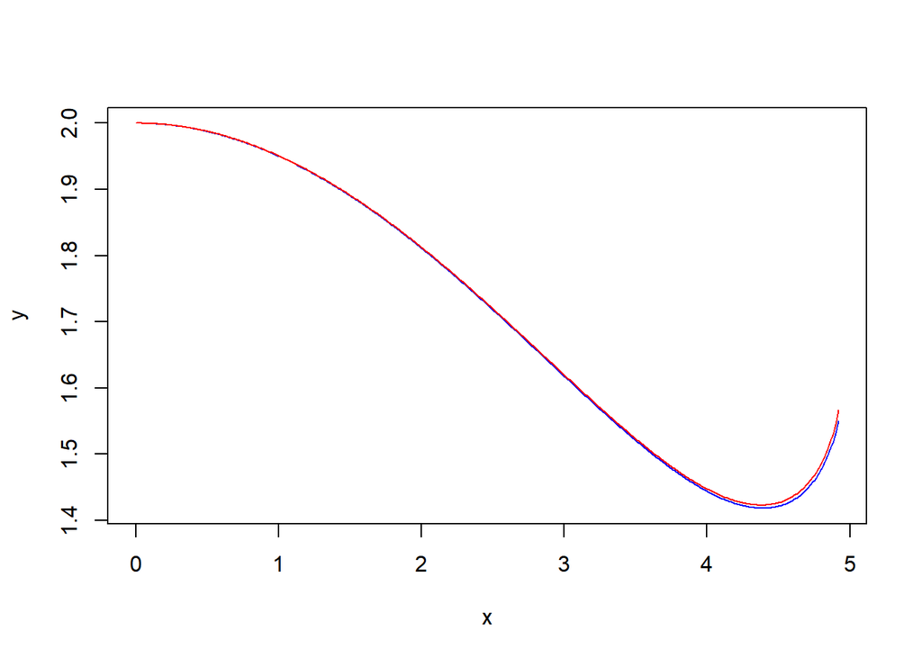

```r
lines(x, u, col="red")
```

Как видим, расхождения в численном и точном решении есть. И оно будет еще большим, если мы выберем большую $\small h$. Вот пример с $\small h = 0.1$:

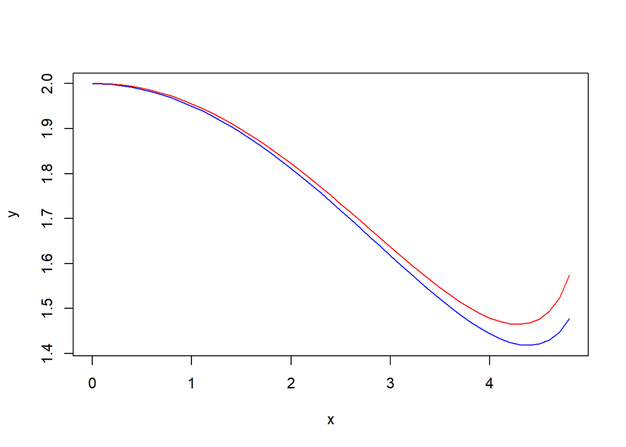

И так, как мы видим, чем грубее взят шаг, тем более начинают расходиться графики. Чтобы численное решение было как можно более приближено к точному, нужно брать как можно меньший шаг, но для вычисления такого количества информации компьютеру может понадобиться больше времени.

Вот итоговый код и график, что мы получили для данной задачи (0):

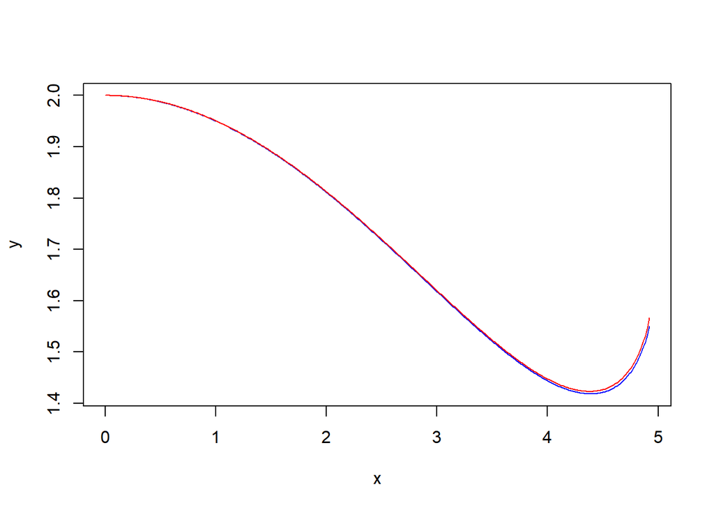

```r
h = 1e-2
x = seq(0, pi^2/2, h)
x = x[-length(x)]

y = (log(abs(cos(x/pi))) + 2) * cos(x/pi) + (x/pi)*sin(x/pi)
plot(x,y, type = "l", col = "blue")

u = c(2 , 2)
n = 3:(length(x))
for(n in 3:(length(x))){
  u = c(u,(-u[n-2] + u[n-1] * (2 - (h^2/pi^2)) + (h^2)/(cos(x[n]/pi) * pi^2)))
}
lines(x, u, col="red")
```

Дополнительно можно прописать переменные, которые численно покажут, насколько решения отличаются. Но лабораторная работа этого не требует, поэтому можете сделать сами, если будет интерес.